# Using Tidyverts with the Australian retail data: introduction and exploration

## The Tidyverts family

[**Tidyverts**](https://tidyverts.org) is a family of R packages for time series analysis and forecasting. It is the work of Rob Hyndman, professor of statistics at Monash University, and his team. The family is intended to be the next-generation replacement for the very popular `forecast` package, and is currently under active development. The purpose of this document is to provide a quick overview of the capabilities and features of Tidyverts.

## Data manipulation and summaries

Tidyverts is designed to integrate with the [Tidyverse](https://tidyverse.org), the de facto standard for data analytics workflows in R (the similarity in names is something of an in-joke). In particular, it defines a new data structure called a *tsibble*, which is an extended version of a tibble for working with time series. You can use all the standard dplyr/purrr verbs with tsibbles.

Let’s look at how to do some simple summaries. We’ll use the `aus_retail` dataset, which contains retail turnover statistics by (Australian) state and industry, going back to 1982. This is part of the tsibbledata package, which contains several example time series datasets.

```r
library(dplyr)
library(tsibbledata)
library(tsibble)
library(feasts)
library(fable)

slice(aus_retail, 1:6)
```

| State | Industry | Series ID | Month | Turnover |
| --- | --- | --- | --- | --- |
| Australian Capital Territory | Cafes, restaurants and catering services | A3349849A | 1982 Apr | 4.4 |
| Australian Capital Territory | Cafes, restaurants and catering services | A3349849A | 1982 May | 3.4 |
| Australian Capital Territory | Cafes, restaurants and catering services | A3349849A | 1982 Jun | 3.6 |
| Australian Capital Territory | Cafes, restaurants and catering services | A3349849A | 1982 Jul | 4.0 |
| Australian Capital Territory | Cafes, restaurants and catering services | A3349849A | 1982 Aug | 3.6 |
| Australian Capital Territory | Cafes, restaurants and catering services | A3349849A | 1982 Sep | 4.2 |

A tsibble includes two attributes to hold the time series information in the data:

- An *index*, which is the time variable
- Optionally, one or more *keys*, which identify separate time series within the dataset

In the `aus_retail` dataset, the index is `Month`, with a range from April 1982 to December 2018. The keys are `State` and `Industry`, meaning that the data contains one time series for each combination of these variables.

```r
key_vars(aus_retail)
```

```
[1] "State"    "Industry"
```

```
State

Industry
```

```r
index_var(aus_retail)
```

```
[1] "Month"
```

```
Month
```

```r
range(aus_retail$Month)
```

```
<yearmonth[2]>
[1] "1982 Apr" "2018 Dec"
```

One thing to be aware of when summarising a tsibble with `group_by/summarise` is that the index variable is automatically included in the groups. This lets you easily aggregate lower-level time series into higher-level ones. However, if you want to aggregate over the index itself, you have to convert to a *tibble* first. Let’s look at the total turnover by industry and by state.

```r
aus_retail %>%
    as_tibble() %>%
    group_by(Industry) %>%
    summarise(Turnover=sum(Turnover))
```

|  | Industry | Turnover |
| --- | --- | --- |
| 1 | Cafes, restaurants and catering services | 414431.2 |
| 2 | Cafes, restaurants and takeaway food services | 741912.6 |
| 3 | Clothing retailing | 324124.1 |
| 4 | Clothing, footwear and personal accessory retailing | 492355.6 |
| 5 | Department stores | 487129.3 |
| 6 | Electrical and electronic goods retailing | 435935.7 |
| 7 | Food retailing | 2278544.8 |
| 8 | Footwear and other personal accessory retailing | 168230.4 |
| 9 | Furniture, floor coverings, houseware and textile goods retailing | 286170.1 |
| 10 | Hardware, building and garden supplies retailing | 330429.6 |

[output cut: 10 more lines]

```r
aus_retail %>%
    as_tibble() %>%
    group_by(State) %>%
    summarise(Turnover=sum(Turnover))
```

|  | State | Turnover |
| --- | --- | --- |
| 1 | Australian Capital Territory | 211366.7 |
| 2 | New South Wales | 3685679.7 |
| 3 | Northern Territory | 97203.1 |
| 4 | Queensland | 2152508.3 |
| 5 | South Australia | 786950.1 |
| 6 | Tasmania | 199168.6 |
| 7 | Victoria | 2851855.4 |
| 8 | Western Australia | 1228212.5 |

Other methods provided for grouping and summarising tsibbles include `index_by`, which lets you manipulate how the index variable is treated as a grouping variable; and `group_by_key`, which automatically groups by the key variables.

## Plotting the data

Let’s have a look at the trends in the data over time. Tidyverts defines a `ggplot::autoplot` method for tsibbles, which is intended to give you a reasonable plot for a time series. When given a dataset with keys, it will produce a separate time plot for each key combination. For this dataset, there are about $8 \times 20 = 160$ combinations, which is too many to show on a single plot; instead, let’s look at the state-level aggregation.

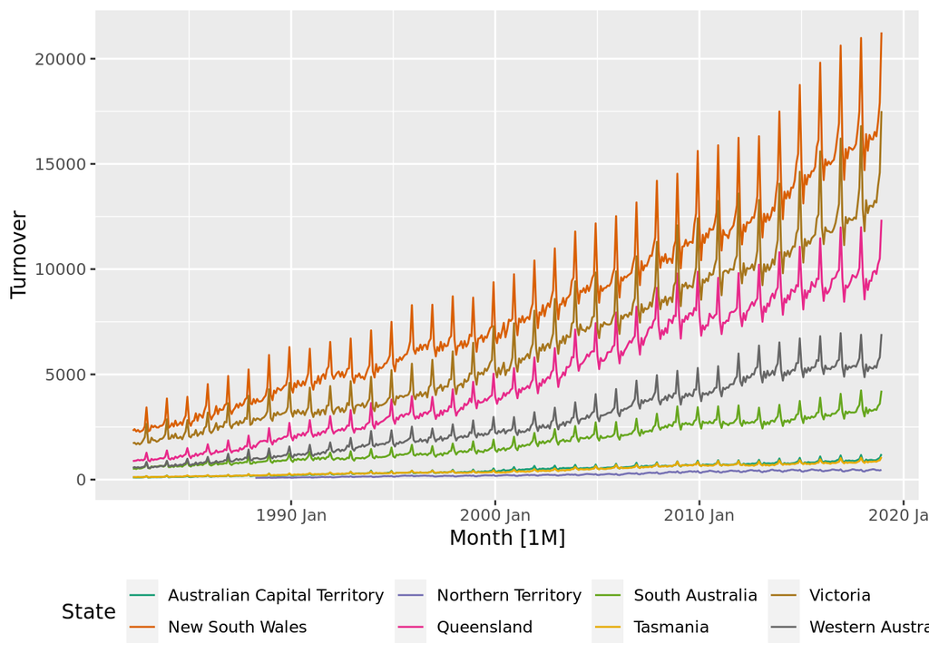

```r
library(ggplot2)

aus_retail %>%
    group_by(State) %>%  # we don't need to include Month in the groups
    summarise(Turnover=sum(Turnover)) %>%
    autoplot(Turnover) +
        theme(legend.position="bottom") +
        scale_color_brewer(palette="Dark2")
```

Observations about this plot:

- There is a very obvious increasing trend over time, which is to be expected given general economic growth.
- There is also very strong seasonality, with a spike in December reflecting Christmas spending.
- Both trend and seasonality appear to be multiplicative.

Repeating the plot on the log scale confirms the multiplicative nature of the data, and also highlights differences between states in their trends over the period.

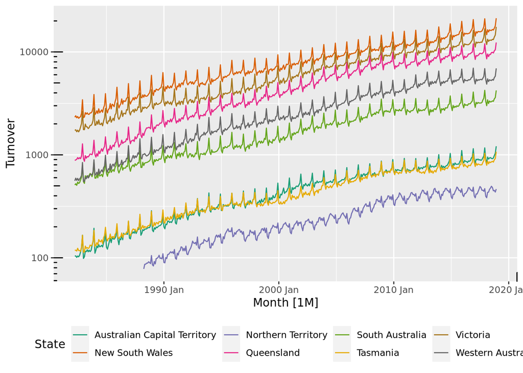

```r
aus_retail %>%
    group_by(State) %>%
    summarise(Turnover=sum(Turnover)) %>%
    autoplot(Turnover) +
        theme(legend.position="bottom") +
        scale_color_brewer(palette="Dark2") +
        scale_y_log10() +
        annotation_logticks()
```

We can also look at the corresponding plots for some individual industries, with a suitably defined helper function.

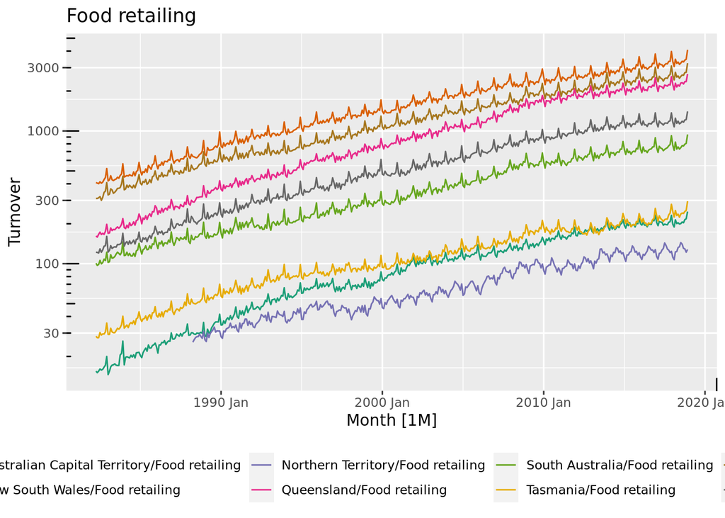

```r
industry_autologplot <- function(industry)
{
    aus_retail %>%
        filter(Industry == industry) %>%
        select(-Industry) %>%
        autoplot(Turnover) +
            theme(legend.position="bottom") +
            scale_color_brewer(palette="Dark2") +
            scale_y_log10() +
            annotation_logticks() +
            ggtitle(industry)
}

industry_autologplot("Food retailing")
```

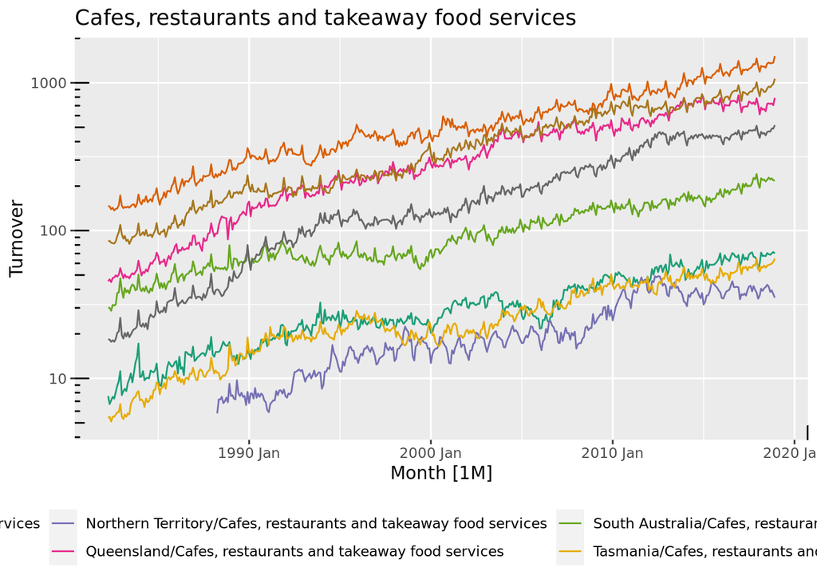

```r
industry_autologplot("Cafes, restaurants and takeaway food services")
```

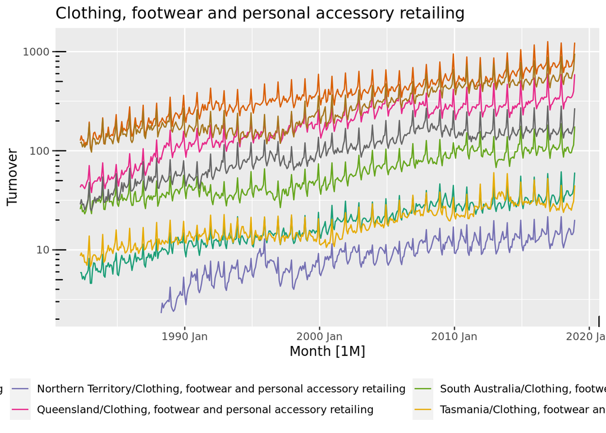

```r
industry_autologplot("Clothing, footwear and personal accessory retailing")
```

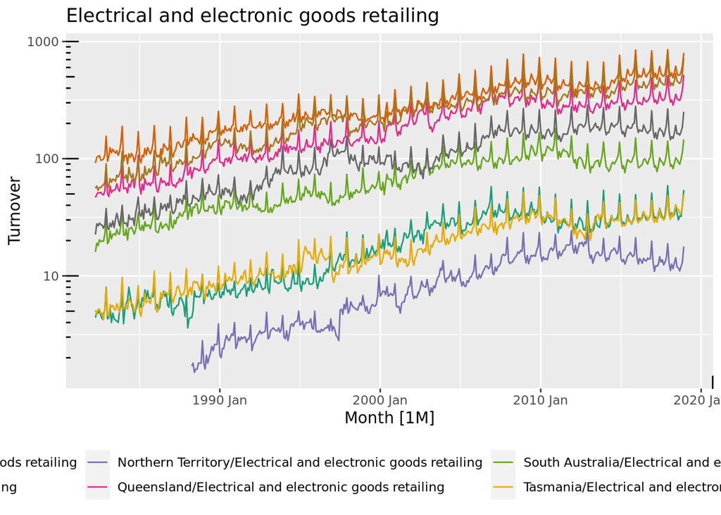

```r
industry_autologplot("Electrical and electronic goods retailing")
```

[figure not shown]

```r
aus_retail %>%
    filter(Industry == "Food retailing", State == "New South Wales") %>%
    gg_season(Turnover) +
        scale_y_log10() +
        annotation_logticks() +
        ggtitle("Food retailing/New South Wales")
```

[figure not shown]

```r
aus_retail %>%
    filter(Industry == "Food retailing", State == "New South Wales") %>%
    gg_subseries(Turnover) +
        scale_y_log10() +
        annotation_logticks() +
        ggtitle("Food retailing/New South Wales")
```

For this dataset though, these plots are probably less helpful because of the large number of years.